# Sarah McCutcheon Env-Info. Lab 2 & 3

```r
# set working directory if has child directory
dir_child = 'students'
if (dir_child %in% list.files()){
  if (interactive()) {
    # R Console
    setwd(dir_child)
  } else {
    # knitting
    knitr::opts_knit$set(root.dir=dir_child)
  }
}
```

## Lab 2, HW 1

#### Organization

fire-mitigation

### Content

```
What is your burning environmental question that you would like to address? Feel free to provide group project, dissertation, and/or personal interest. What is the study area?
```

I would like to determine what California cities are most like Santa Barbara in regards to wildfire potential. I would like to create a weighted model, from expert opinion, to select cities based on the weighted factors.

### Techniques

```
What techniques from the course do you think will be most applicable?
```

I think the lessons on interactive plots and maps will be most useful to my specific question. I also believe, that the wrangling data and visualizing data lessons will be useful overall to my future career.

#### Data

```
What data have you already identified? Feel free to provide a link and/or details on the variables of interest.
```

The data that we will use for our weighted model will come from two sources. One will be the various data layers that we have for GIS (e.g. vegetation, wildland urban interface, census, fire history, and jurisdictional layers). Our second data source will be a collective weight that is assigned to each of those variables based on the expert opinion. We are collecting that information on Thursday, January 21st from members of the Santa Barbara Fire Safe Council using the [analytical hierarchy process](https://en.wikipedia.org/wiki/Analytic_hierarchy_process).

#### Our Process

1. Collect expert opinion on weighted factors using AHP survey
2. Collect and organize necessary map layers
   - Get GIS layers
   - Clean them up and organize attribute table to show only the data that is needed
3. Combine the weighted factors and the layers in a GIS model to select the appropriate cities

### Image

```
2010 WUI Map
```

A map of the *most recent* comprehensive calculation of total wildland urban intermix in the US is shown below. The map was created by the **US Forest Service**.

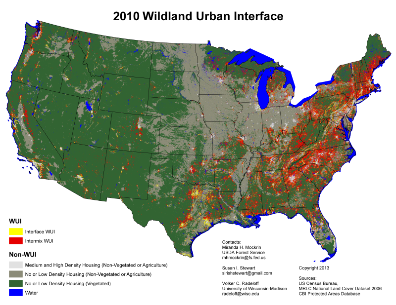

### Data File

```r
#read csv
d=read.csv('data/smccutcheon_FullData.csv')

#output summary
summary(d)
```

```
##      years          fireRisk           vote         districtBen
##  Min.   : 0.20   Min.   : 1.000   Min.   : 0.000   Min.   : 1.000
##  1st Qu.:10.00   1st Qu.: 3.000   1st Qu.: 1.000   1st Qu.: 4.000
##  Median :18.00   Median : 4.000   Median : 1.000   Median : 4.000
##  Mean   :22.63   Mean   : 6.342   Mean   : 4.071   Mean   : 7.222
##  3rd Qu.:33.00   3rd Qu.: 5.000   3rd Qu.: 2.000   3rd Qu.: 5.000
##  Max.   :74.80   Max.   :69.000   Max.   :69.000   Max.   :69.000
##   districtSuc      districtSafe        forest            evac
##  Min.   : 1.000   Min.   : 1.000   Min.   : 1.000   Min.   : 0.000
##  1st Qu.: 3.000   1st Qu.: 3.000   1st Qu.: 3.000   1st Qu.: 1.000
##  Median : 4.000   Median : 4.000   Median : 4.000   Median : 1.000
##  Mean   : 7.145   Mean   : 7.191   Mean   : 7.417   Mean   : 2.545
##  3rd Qu.: 5.000   3rd Qu.: 5.000   3rd Qu.: 5.000   3rd Qu.: 1.000
##  Max.   :69.000   Max.   :69.000   Max.   :69.000   Max.   :69.000
##       chip            noChip         defense         noDefense
##  Min.   : 0.000   Min.   : 0.00   Min.   : 0.000   Min.   : 0.00
##  1st Qu.: 0.000   1st Qu.: 4.00   1st Qu.: 0.000   1st Qu.: 3.00
##  Median : 1.000   Median :69.00   Median : 0.000   Median : 5.00
##  Mean   : 2.908   Mean   :41.88   Mean   : 2.969   Mean   :34.47
##  3rd Qu.: 2.000   3rd Qu.:69.00   3rd Qu.: 1.000   3rd Qu.:69.00
##  Max.   :69.000   Max.   :69.00   Max.   :69.000   Max.   :69.00
##     lostHome         ownRent            income           eth
##  Min.   : 0.000   Min.   : 0.0000   Min.   : 1.00   Min.   : 1.00
##  1st Qu.: 0.000   1st Qu.: 0.0000   1st Qu.: 2.00   1st Qu.: 1.00
##  Median : 0.000   Median : 0.0000   Median : 3.00   Median : 1.00
##  Mean   : 2.176   Mean   : 0.3459   Mean   :25.62   Mean   :18.54
##  3rd Qu.: 0.000   3rd Qu.: 0.0000   3rd Qu.:69.00   3rd Qu.:69.00
##  Max.   :69.000   Max.   :69.0000   Max.   :69.00   Max.   :69.00
##    spouseEth          edu
##  Min.   : 1.00   Min.   : 2.00
##  1st Qu.: 1.00   1st Qu.: 3.00
##  Median : 1.00   Median : 4.00
##  Mean   :31.92   Mean   :19.58
##  3rd Qu.:69.00   3rd Qu.: 4.00
##  Max.   :69.00   Max.   :69.00
```

## Lab 3, HW 2

### Data Wrangling

```r
# list of packages
pkgs = c(
  'readr',        # read csv
  'readxl',       # read xls
  'dplyr',        # data frame manipulation
  'tidyr',        # data tidying
  'nycflights13', # test dataset of NYC flights for 2013
  'gapminder')    # test dataset of life expectancy and popultion

# install packages if not found
for (p in pkgs){
  if (!require(p, character.only=T)){
    install.packages(p)
  }
}
```

#### Traditional csv read

```r
d = read.csv('../data/r-ecology/species.csv')
d
```

```
##    species_id            genus         species    taxa
## 1          AB       Amphispiza       bilineata    Bird
## 2          AH Ammospermophilus         harrisi  Rodent
## 3          AS       Ammodramus      savannarum    Bird
## 4          BA          Baiomys         taylori  Rodent
## 5          CB  Campylorhynchus brunneicapillus    Bird
## 6          CM      Calamospiza     melanocorys    Bird
## 7          CQ       Callipepla        squamata    Bird
## 8          CS         Crotalus      scutalatus Reptile
## 9          CT    Cnemidophorus          tigris Reptile
## 10         CU    Cnemidophorus       uniparens Reptile
## 11         CV         Crotalus         viridis Reptile
## 12         DM        Dipodomys        merriami  Rodent
## 13         DO        Dipodomys           ordii  Rodent
## 14         DS        Dipodomys     spectabilis  Rodent
```

[output cut: 40 more lines]

```r
head(d)
```

```
##   species_id            genus         species   taxa
## 1         AB       Amphispiza       bilineata   Bird
## 2         AH Ammospermophilus         harrisi Rodent
## 3         AS       Ammodramus      savannarum   Bird
## 4         BA          Baiomys         taylori Rodent
## 5         CB  Campylorhynchus brunneicapillus   Bird
## 6         CM      Calamospiza     melanocorys   Bird
```

```r
summary(d)
```

```
##    species_id             genus         species        taxa
##  AB     : 1   Chaetodipus    : 4   sp.      :10   Bird   :13
##  AH     : 1   Dipodomys      : 4   hispidus : 2   Rabbit : 1
##  AS     : 1   Reithrodontomys: 4   albigula : 1   Reptile: 9
##  BA     : 1   Sigmodon       : 4   audubonii: 1   Rodent :31
##  CB     : 1   Onychomys      : 3   baileyi  : 1
##  CM     : 1   Peromyscus     : 3   bilineata: 1
##  (Other):48   (Other)        :32   (Other)  :38
```

#### Using readr to read csv

```r
library(readr)

d = read_csv('../data/r-ecology/species.csv')
d
```

```
##    species_id            genus         species    taxa
## 1          AB       Amphispiza       bilineata    Bird
## 2          AH Ammospermophilus         harrisi  Rodent
## 3          AS       Ammodramus      savannarum    Bird
## 4          BA          Baiomys         taylori  Rodent
## 5          CB  Campylorhynchus brunneicapillus    Bird
## 6          CM      Calamospiza     melanocorys    Bird
## 7          CQ       Callipepla        squamata    Bird
## 8          CS         Crotalus      scutalatus Reptile
## 9          CT    Cnemidophorus          tigris Reptile
## 10         CU    Cnemidophorus       uniparens Reptile
## 11         CV         Crotalus         viridis Reptile
## 12         DM        Dipodomys        merriami  Rodent
## 13         DO        Dipodomys           ordii  Rodent
## 14         DS        Dipodomys     spectabilis  Rodent
```

[output cut: 40 more lines]

```r
head(d)
```

```
##   species_id            genus         species   taxa
## 1         AB       Amphispiza       bilineata   Bird
## 2         AH Ammospermophilus         harrisi Rodent
## 3         AS       Ammodramus      savannarum   Bird
## 4         BA          Baiomys         taylori Rodent
## 5         CB  Campylorhynchus brunneicapillus   Bird
## 6         CM      Calamospiza     melanocorys   Bird
```

```r
summary(d)
```

```
##   species_id           genus             species
##  Length:54          Length:54          Length:54
##  Class :character   Class :character   Class :character
##  Mode  :character   Mode  :character   Mode  :character
##      taxa
##  Length:54
##  Class :character
##  Mode  :character
```

#### Code using basic functions only

```r
#read in csv
surveys = read.csv('../data/r-ecology/surveys.csv')

# view data
head (surveys)
```

```
##   record_id month day year plot_id species_id sex hindfoot_length weight
## 1         1     7  16 1977       2         NL   M              32     NA
## 2         2     7  16 1977       3         NL   M              33     NA
## 3         3     7  16 1977       2         DM   F              37     NA
## 4         4     7  16 1977       7         DM   M              36     NA
## 5         5     7  16 1977       3         DM   M              35     NA
## 6         6     7  16 1977       1         PF   M              14     NA
```

```r
summary (surveys)
```

```
##    record_id         month             day             year
##  Min.   :    1   Min.   : 1.000   Min.   : 1.00   Min.   :1977
##  1st Qu.: 8888   1st Qu.: 4.000   1st Qu.: 9.00   1st Qu.:1984
##  Median :17775   Median : 6.000   Median :16.00   Median :1990
##  Mean   :17775   Mean   : 6.474   Mean   :16.11   Mean   :1990
##  3rd Qu.:26662   3rd Qu.: 9.000   3rd Qu.:23.00   3rd Qu.:1997
##  Max.   :35549   Max.   :12.000   Max.   :31.00   Max.   :2002
##
##     plot_id       species_id    sex       hindfoot_length     weight
##  Min.   : 1.0   DM     :10596    : 2506   Min.   : 2.00   Min.   :  4.00
##  1st Qu.: 5.0   PP     : 3123   F:15690   1st Qu.:21.00   1st Qu.: 20.00
##  Median :11.0   DO     : 3027   M:17348   Median :32.00   Median : 37.00
##  Mean   :11.4   PB     : 2891   P:    1   Mean   :29.29   Mean   : 42.67
##  3rd Qu.:17.0   RM     : 2609   R:    3   3rd Qu.:36.00   3rd Qu.: 48.00
##  Max.   :24.0   DS     : 2504   Z:    1   Max.   :70.00   Max.   :280.00
##                 (Other):10799             NA's   :4111    NA's   :3266
```

```r
# limit columns to species and year
surveys_2 = surveys[,c('species_id', 'year')]

# limit rows to just species "NL"
surveys_3 = surveys_2[,c('species_id', 'year')]

# get count per year
surveys_4 = aggregate(species_id ~ year, data=surveys_3, FUN= 'length')

# write to csv
write.csv(surveys_4, 'data/surveys_smccutcheon.csv', row.names = FALSE)
```

#### Code using nested functions

```r
# read in data
surveys = read.csv('../data/r-ecology/surveys.csv')

# view data
head(surveys)
```

```
##   record_id month day year plot_id species_id sex hindfoot_length weight
## 1         1     7  16 1977       2         NL   M              32     NA
## 2         2     7  16 1977       3         NL   M              33     NA
## 3         3     7  16 1977       2         DM   F              37     NA
## 4         4     7  16 1977       7         DM   M              36     NA
## 5         5     7  16 1977       3         DM   M              35     NA
## 6         6     7  16 1977       1         PF   M              14     NA
```

```r
summary(surveys)
```

```
##    record_id         month             day             year
##  Min.   :    1   Min.   : 1.000   Min.   : 1.00   Min.   :1977
##  1st Qu.: 8888   1st Qu.: 4.000   1st Qu.: 9.00   1st Qu.:1984
##  Median :17775   Median : 6.000   Median :16.00   Median :1990
##  Mean   :17775   Mean   : 6.474   Mean   :16.11   Mean   :1990
##  3rd Qu.:26662   3rd Qu.: 9.000   3rd Qu.:23.00   3rd Qu.:1997
##  Max.   :35549   Max.   :12.000   Max.   :31.00   Max.   :2002
##
##     plot_id       species_id    sex       hindfoot_length     weight
##  Min.   : 1.0   DM     :10596    : 2506   Min.   : 2.00   Min.   :  4.00
##  1st Qu.: 5.0   PP     : 3123   F:15690   1st Qu.:21.00   1st Qu.: 20.00
##  Median :11.0   DO     : 3027   M:17348   Median :32.00   Median : 37.00
##  Mean   :11.4   PB     : 2891   P:    1   Mean   :29.29   Mean   : 42.67
##  3rd Qu.:17.0   RM     : 2609   R:    3   3rd Qu.:36.00   3rd Qu.: 48.00
##  Max.   :24.0   DS     : 2504   Z:    1   Max.   :70.00   Max.   :280.00
##                 (Other):10799             NA's   :4111    NA's   :3266
```

```r
# limit data with [], aggregate to count, write to csv
write.csv(
  aggregate(
    species_id ~ year,
    data = surveys[surveys_2$species_id  == 'NL', c('species_id', 'year')],
    FUN = 'length'),
  'data/surveys_smccutcheon.csv',
  row.names = FALSE)
```

#### Code using dplyr

```r
# load libraries
library(readr)
library(dplyr)

# read in csv
surveys = read_csv('../data/r-ecology/surveys.csv')

# dplyr elegance
surveys %T>%                          # note tee operator %T>% for glimpse
  glimpse() %>%                       # view data
  select(species_id, year) %>%        # limit columns
  filter(species_id  == 'NL') %>%     # limit rows
  group_by(year) %>%                  # get count by first grouping
  summarize(n = n()) %>%              #   then summarize
  write_csv('data/surveys_smccutcheon.csv') # write out csv
```

```
## Observations: 35,549
## Variables: 9
## $ record_id       (int) 1, 2, 3, 4, 5, 6, 7, 8, 9, 10, 11, 12, 13, 14,...
## $ month           (int) 7, 7, 7, 7, 7, 7, 7, 7, 7, 7, 7, 7, 7, 7, 7, 7...
## $ day             (int) 16, 16, 16, 16, 16, 16, 16, 16, 16, 16, 16, 16...
## $ year            (int) 1977, 1977, 1977, 1977, 1977, 1977, 1977, 1977...
## $ plot_id         (int) 2, 3, 2, 7, 3, 1, 2, 1, 1, 6, 5, 7, 3, 8, 6, 4...
## $ species_id      (chr) "NL", "NL", "DM", "DM", "DM", "PF", "PE", "DM"...
## $ sex             (chr) "M", "M", "F", "M", "M", "M", "F", "M", "F", "...
## $ hindfoot_length (int) 32, 33, 37, 36, 35, 14, NA, 37, 34, 20, 53, 38...
## $ weight          (int) NA, NA, NA, NA, NA, NA, NA, NA, NA, NA, NA, NA...
```

## Week 4, Tidy Data

#### EDAWR

```r
# install.packages("devtools")
#devtools::install_github("rstudio/EDAWR")
library(EDAWR)
help(package='EDAWR')
?storms    # wind speed data for 6 hurricanes
?cases     # subset of WHO tuberculosis
?pollution # pollution data from WHO Ambient Air Pollution, 2014
?tb        # tuberculosis data
View(storms)
View(cases)
View(pollution)
```

### slicing

```r
# storms
storms$storm
storms$wind
storms$pressure
storms$date

# cases
cases$country
names(cases)[-1]
unlist(cases[1:3, 2:4])

# pollution
pollution$city[c(1,3,5)]
pollution$amount[c(1,3,5)]
pollution$amount[c(2,4,6)]

# ratio
storms$pressure / storms$wind
```

#### tidyr

Two main functions: gather() and spread()

```r
# install.packages("tidyr")
library(tidyr)
??gather # gather to long
??spread # spread to wide
```

### `gather`

```r
cases
gather(cases, "year", "n", 2:4)

cases

library(dplyr)
d2<-cases %>%
  gather("year", "n", -country) %>%
  filter(
    year %in% c(2011, 2013) &
      !country %in% c('FR', 'US'))
d2
```

### `spread`

```r
pollution
spread(pollution, size, amount)
```

Other functions to extract and combine columns…

### `separate`

```r
storms
storms2 = separate(storms, date, c("year", "month", "day"), sep = "-")
```

### `unite`

```r
storms2
unite(storms2, "date", year, month, day, sep = "-")
```

#### tidy CO<sub>2</sub> emissions

#### **Task**. Convert the following table [CO<sub>2</sub> emissions per country since 1970](http://edgar.jrc.ec.europa.eu/overview.php?v=CO2ts1990-2014&sort=des9) from wide to long format and output the first few rows into your Rmarkdown. I recommend consulting `?gather` and you should have 3 columns in your output._

```r
library(readxl) # install.packages('readxl')

url = 'http://edgar.jrc.ec.europa.eu/news_docs/CO2_1970-2014_dataset_of_CO2_report_2015.xls'
xls = '../data/co2_europa.xls'

print(getwd())
if (!file.exists(xls)){
  download.file(url, xls)
}
co2 = read_excel(xls, skip=12)
co2
```

**Question**. Why use `skip=12` argument in `read_excel()`?

#### dplyr

A package that helps transform tabular data

```r
# install.packages("dplyr")
library(dplyr)
?select
?filter
?arrange
?mutate
?group_by
?summarise
```

See sections in the data-wrangling-cheatsheet.pdf:

- Subset Variables (Columns), eg `select()`
- Subset Observations (Rows), eg `filter()`
- Reshaping Data - Change the layout of a data set, eg `arrange()`
- Make New Variables, eg `mutate()`
- Group Data, eg `group_by()` and `summarise()`

#### `select`

```r
storms
select(storms, storm, pressure)
storms %>% select(storm, pressure)
```

#### `filter`

```r
storms
filter(storms, wind >= 50)
storms %>% filter(wind >= 50)

storms %>%
  filter(wind >= 50) %>%
  select(storm, pressure)
```

#### `mutate`

```r
storms %>%
  mutate(ratio = pressure / wind) %>%
  select(storm, ratio)
```

#### `group_by`

```r
pollution
pollution %>% group_by(city)
```

#### `summarise`

```r
# by city
pollution %>%
  group_by(city) %>%
  summarise(
    mean = mean(amount),
    sum = sum(amount),
    n = n())

# by size
pollution %>%
  group_by(size) %>%
  summarise(
    mean = mean(amount),
    sum = sum(amount),
    n = n())
```

note that `summarize` synonymously works

#### `ungroup`

```r
pollution %>%
  group_by(size)

pollution %>%
  group_by(size) %>%
  ungroup()
```

#### multiple groups

```r
tb %>%
  group_by(country, year) %>%
  summarise(cases = sum(cases))
  summarise(cases = sum(cases))
```

**Recap: dplyr**:

- Extract columns with `select()` and rows with `filter()`
- Sort rows by column with `arrange()`
- Make new columns with `mutate()`
- Group rows by column with `group_by()` and `summarise()`

#### summarize CO<sub>2</sub> emissions

**Task**. Report the top 5 emitting countries (not World or EU28) for 2014 using your long format table. (You may need to convert your year column from factor to numeric, eg `mutate(year = as.numeric(as.character(year)))`. As with most analyses, there are multiple ways to do this. I used the following functions: `filter`, `arrange`, `desc`, `head`).

**Task**. Summarize the total emissions by country (not World or EU28) across years from your long format table and return the top 5 emitting countries. (As with most analyses, there are multiple ways to do this. I used the following functions: `filter`, `arrange`, `desc`, `head`).

#### `bind_cols`

```r
y = data.frame(
  x1 = c('A','B','C'),
  x2 = c( 1 , 2 , 3),
  stringsAsFactors=F)
z = data.frame(
  x1 = c('B','C','D'),
  x2 = c( 2 , 3 , 4),
  stringsAsFactors=F)
y
z
bind_cols(y, z)
```

#### `bind_rows`

```r
y
z
bind_rows(y, z)
```

#### `union`

```r
y
z
union(y, z)
```

#### `intersect`

```r
y
z
intersect(y, z)
```

#### `setdiff`

```r
y
z
setdiff(y, z)
```

#### `left_join`

```r
songs = data.frame(
  song = c('Across the Universe','Come Together', 'Hello, Goodbye', 'Peggy Sue'),
  name = c('John','John','Paul','Buddy'),
  stringsAsFactors=F)
artists = data.frame(
  name = c('George','John','Paul','Ringo'),
  plays = c('sitar','guitar','bass','drums'),
  stringsAsFactors=F)
left_join(songs, artists, by='name')
```

#### `inner_join`

```r
inner_join(songs, artists, by = "name")
```

#### `semi_join`

```r
semi_join(songs, artists, by = "name")
```

#### `anti_join`

```r
anti_join(songs, artists, by = "name")
```

#### summarize per capita CO<sub>2</sub> emissions

You’ll join the gapminder datasets to get world population per country.

**Task**. Report the top 5 emitting countries (not World or EU28) per capita using your long format table. (You may need to convert your year column from factor to numeric, eg `mutate(year = as.numeric(as.character(year)))`. As with most analyses, there are multiple ways to do this. I used the following functions: `filter`, `arrange`, `desc`, `head`).

**Task**. Summarize the total emissions by country (not World or EU28) per capita across years from your long format table and return the top 5 emitting countries. (As with most analyses, there are multiple ways to do this. I used the following functions: `filter`, `arrange`, `desc`, `head`).

```r
library(gapminder) # install.packages('gapminder')
```

## Assignment 4

*Task. Report the top 5 emitting countries (not World or EU28) per capita using your long format table. (You may need to convert your year column from factor to numeric, eg mutate(year = as.numeric(as.character(year))). As with most analyses, there are multiple ways to do this. I used the following functions: filter, arrange, desc, head).

*Task. Summarize the total emissions by country (not World or EU28) per capita across years from your long format table and return the top 5 emitting countries. (As with most analyses, there are multiple ways to do this. I used the following functions: filter, arrange, desc, head).

```r
library(dplyr)
library(readxl) # install.packages('readxl')

url = 'http://edgar.jrc.ec.europa.eu/news_docs/CO2_1970-2014_dataset_of_CO2_report_2015.xls'
xls = '../data/co2_europa.xls'

print(getwd())
```

```
## [1] "C:/Users/sarah/Documents/296/env-info/students"
```

```r
if (!file.exists(xls)){
  download.file(url, xls)
}
co2 = read_excel(xls, skip=12)
```

[output not shown]

```r
co2
```

```
## Source: local data frame [220 x 46]
##
##                Country  1970.000000  1971.000000  1972.000000  1973.000000
##                  (chr)        (dbl)        (dbl)        (dbl)        (dbl)
## 1          Afghanistan  1813.981234  1840.794051  1794.831482  1817.997422
## 2              Albania  4435.433037  4425.968296  5035.309230  4638.057137
## 3              Algeria 18850.745443 22226.320843 34278.432478 46375.728534
## 4       American Samoa     6.183023     6.327022     6.462429     6.587474
## 5               Angola  8946.495011  8532.101439 10382.218539 11365.512295
## 6             Anguilla     2.168006     2.168036     2.263426     2.108604
## 7  Antigua and Barbuda   196.161773   203.964395   244.721752   263.402867
## 8            Argentina 87478.401090 87827.313960 88888.066154 93076.186184
## 9              Armenia 10951.012839 10972.887313 11783.384976 12844.589903
## 10               Aruba    40.380782    40.635025    41.138578    41.949184
## ..                 ...          ...          ...          ...          ...
## Variables not shown: 1974.000000 (dbl), 1975.000000 (dbl), 1976.000000
##   (dbl), 1977.000000 (dbl), 1978.000000 (dbl), 1979.000000 (dbl),
##   1980.000000 (dbl), 1981.000000 (dbl), 1982.000000 (dbl), 1983.000000
##   (dbl), 1984.000000 (dbl), 1985.000000 (dbl), 1986.000000 (dbl),
##   1987.000000 (dbl), 1988.000000 (dbl), 1989.000000 (dbl), 1990.000000
##   (dbl), 1991.000000 (dbl), 1992.000000 (dbl), 1993.000000 (dbl),
##   1994.000000 (dbl), 1995.000000 (dbl), 1996.000000 (dbl), 1997.000000
##   (dbl), 1998.000000 (dbl), 1999.000000 (dbl), 2000.000000 (dbl),
##   2001.000000 (dbl), 2002.000000 (dbl), 2003.000000 (dbl), 2004.000000
##   (dbl), 2005.000000 (dbl), 2006.000000 (dbl), 2007.000000 (dbl),
##   2008.000000 (dbl), 2009.000000 (dbl), 2010.000000 (dbl), 2011.000000
##   (dbl), 2012.000000 (dbl), 2013.000000 (dbl), 2014.000000 (dbl)
```

#### Top 6 Countries by CO2 Emissions

```r
library(dplyr)
library(tidyr)
co2long<-co2 %>%
  gather(Year, "Emissions",  -Country) %>%
  filter(
      !Country %in% c('World', 'EU28'))%>%
  mutate(Year = as.numeric(as.character(Year)))%>%
  group_by(Country)%>%
  summarise(
    TotalEmissions = sum(Emissions))%>%
  arrange(desc(TotalEmissions))

head(co2long)
```

```
## Source: local data frame [6 x 2]
##
##                    Country TotalEmissions
##                      (chr)          (dbl)
## 1 United States of America      231948899
## 2                    China      174045927
## 3       Russian Federation       81242427
## 4                    Japan       51276329
## 5                  Germany       43382205
## 6                    India       39004218
```